# Raport statystyczny - projekt nr 1

Zofia Gruba

2022-05-08

# Opis danych

W zbiorze danych jest 500 obserwacji. Dla każdej obserwacji jest 6 zmiennych ilościowych (wiek, waga, wzrost, liczba dzieci, wydatki, oszczędności) i 3 zmienne jakościowe (płeć, stan cywilny, budynek). Braki danych występują jedynie dla zmiennej płeć - 239 kobiet, 223 mężczyzn oraz 38 braków danych.

W analizie pominę dane, w których występują braki, aby nie zaburzały pozostałych danych. Dodatkowo niektóre testy w R pomijają brakujące dane, dlatego zdecydowałam się nie brać ich pod uwagę.

Zależności w zmiennych objaśniających ilościowych można zaobserować dzięki mapie ciepła przedstawiającej korelację między tymi zmiennymi.

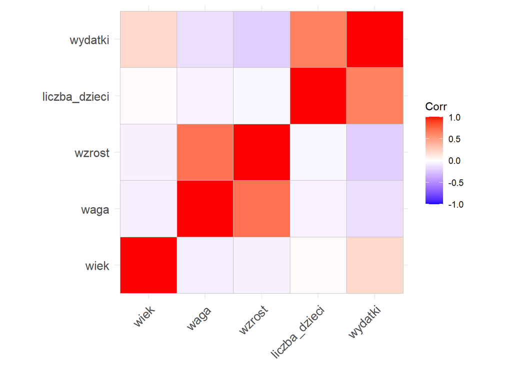

Zaobserwowane zależności między zmiennymi ilościowymi:

- duża korelacja między wagą a wzrostem,
- duża korelacja między liczbą dzieci a wydatkami,
- dość znacząca korelacja między wydatkami a wiekiem,
- prawie zerowa korelacja między liczbą dzieci a wiekiem.

Można zaobserwować również zależności między zmiennymi jakościowymi:

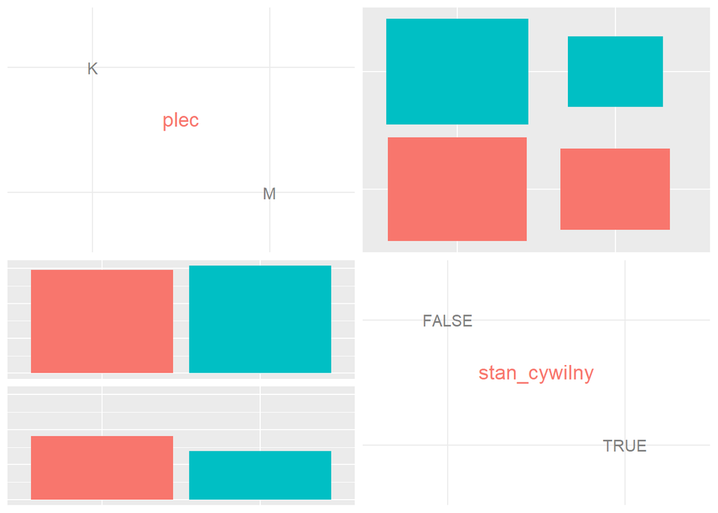

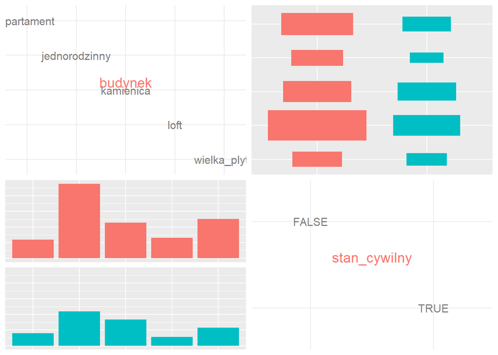

# Podsumowanie danych - wykresy

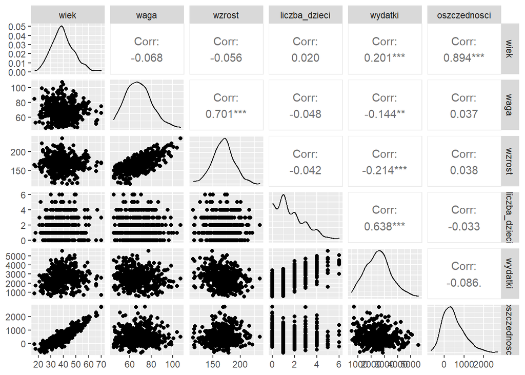

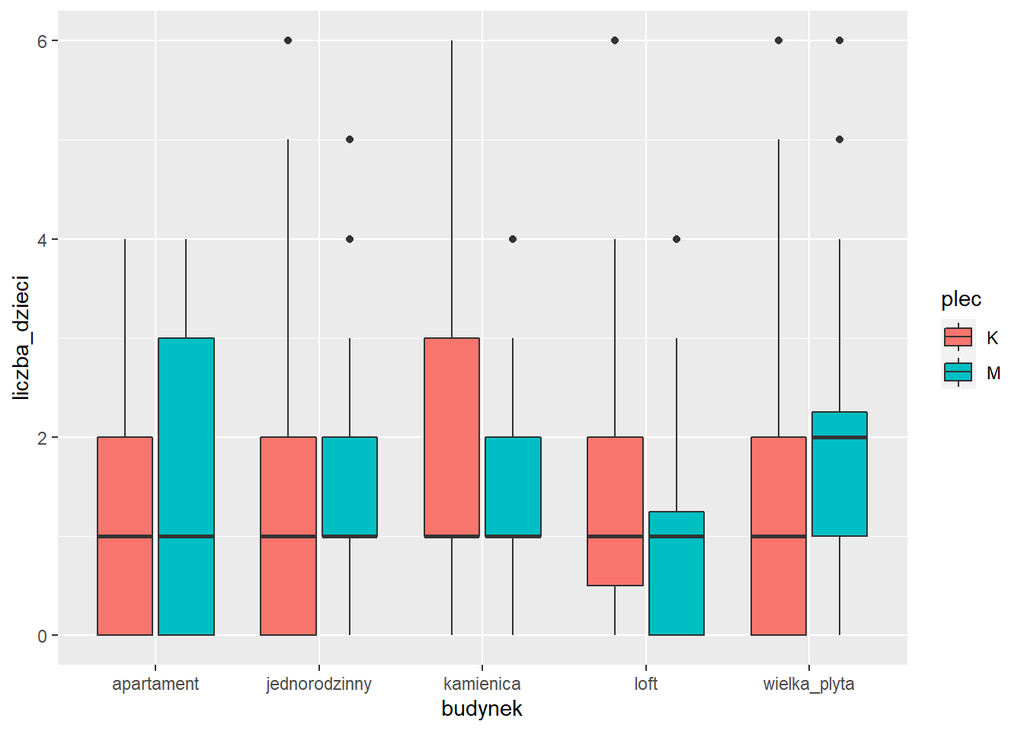

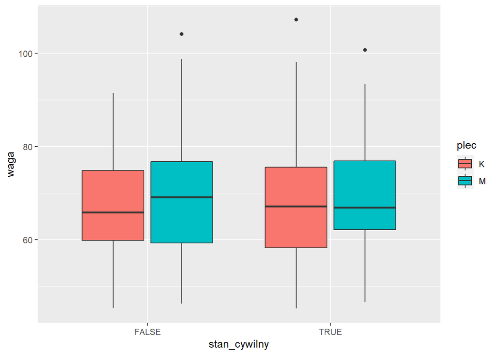

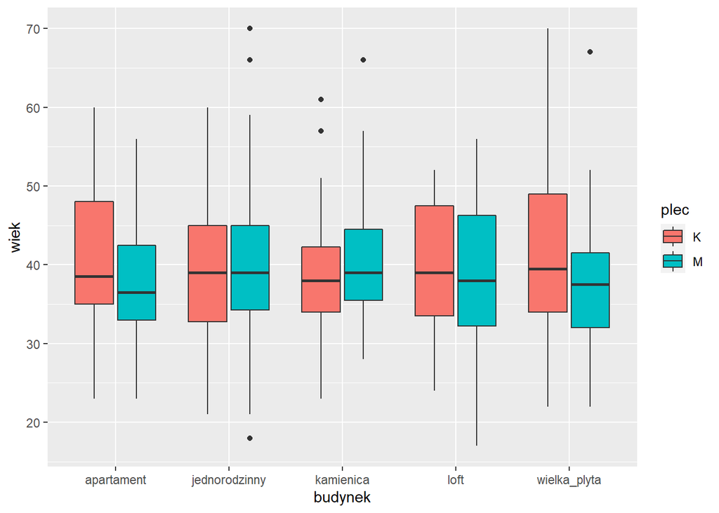

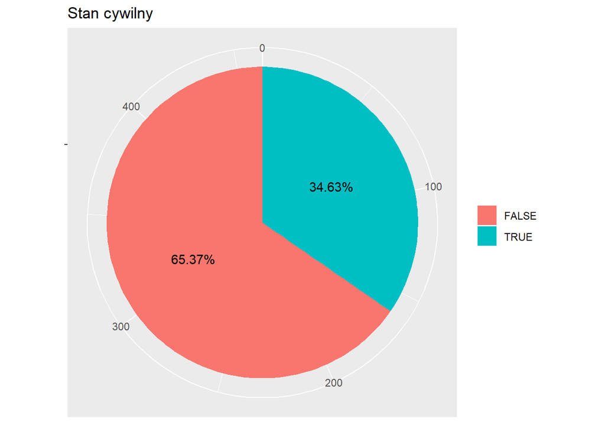

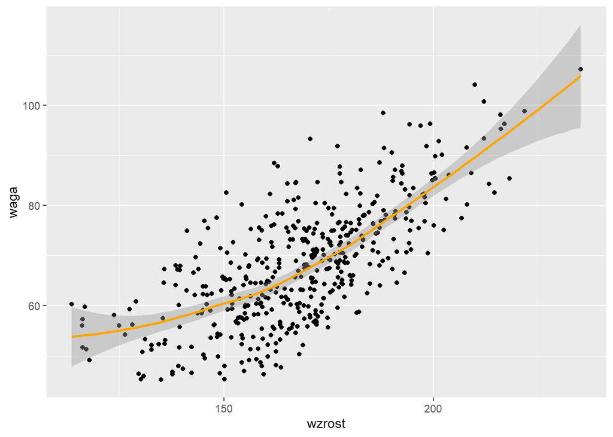

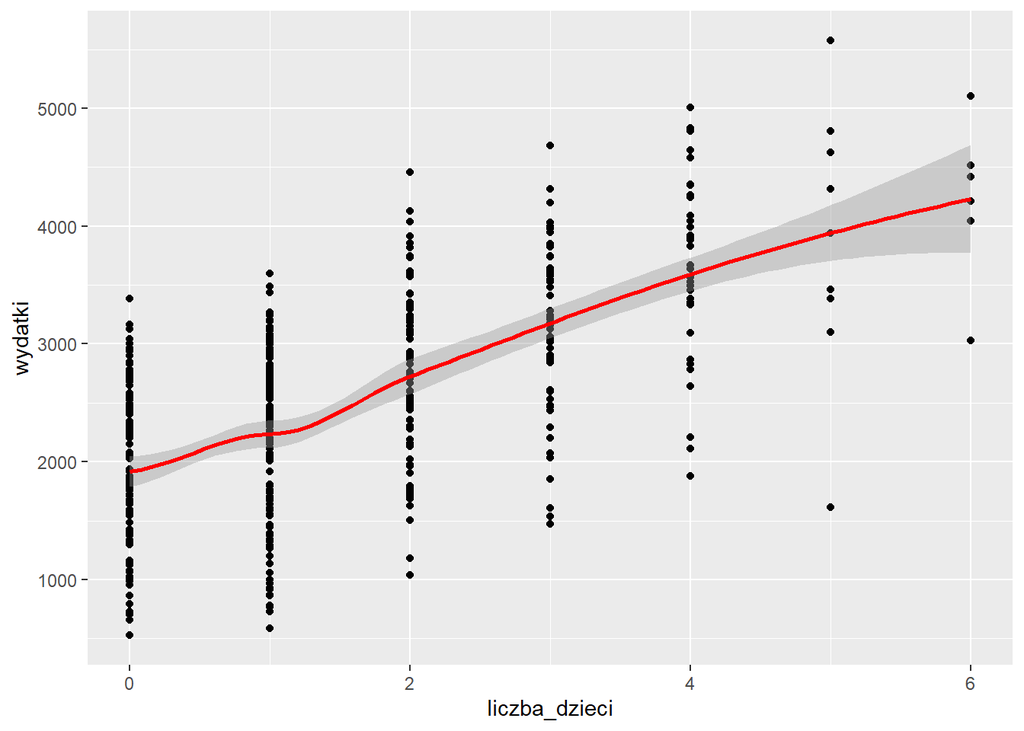

# Średnia i mediana zmiennej **wzrost**

## Hipotezy dotyczące średniej

Mam daną hipotezę zerową $H_0: \mu = 170 cm$, jako hipotezę alternatywną badam hipotezę $H_1: \mu <170 cm$.

Badając tę hipotezę korzystam z testu t-Studenta.

Założenia testu t-Studenta:

- obserwacje w próbce niezależne,
- dane powinny być w przybliżeniu normalnie dystrybuowane.

Założenia dla zmiennej wzrost są spełnione.

Niezależność obserwacji wynika z treści zadania - wzrost różnych osób. Założenia dotyczące normalności można sprawdzić analizując następujące wykresy:

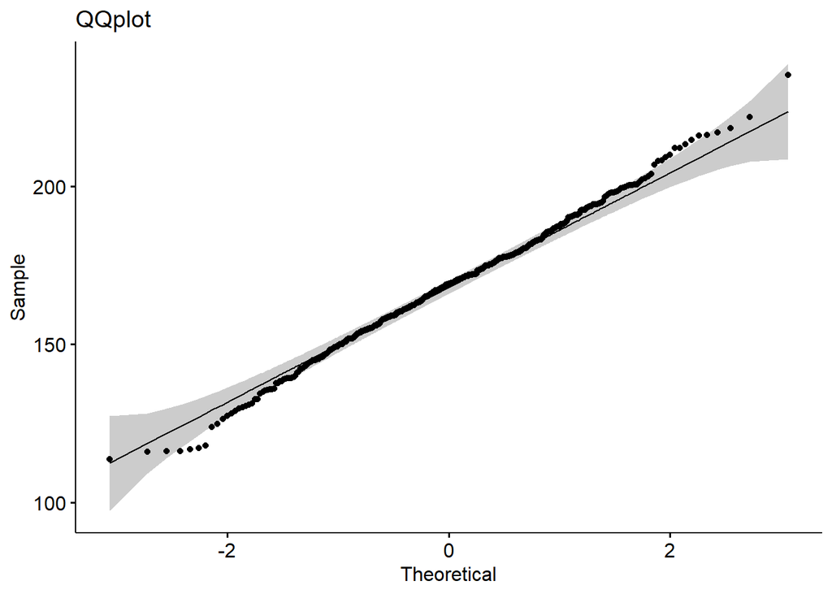

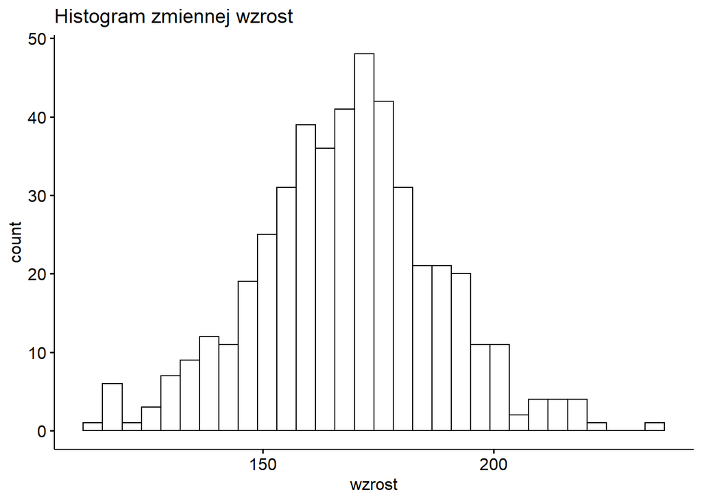

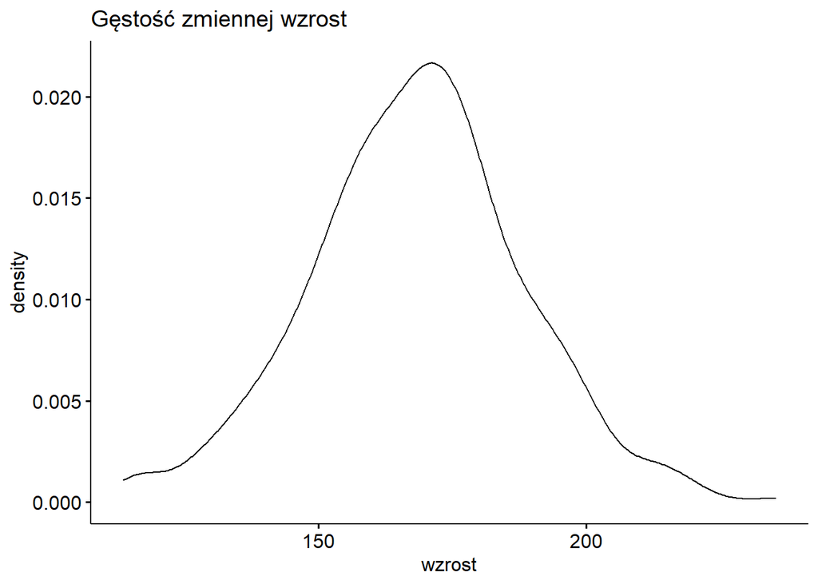

### Wyniki

Korzystając z testu t-Studenta dla wymienionych wcześniej hipotez, otrzymuję p-wartość 0.01949.

## Hipotezy dotyczące mediany

Mam daną hipotezę zerową $H_0: me = 165 cm$, jako hipotezę alternatywną badam hipotezę $H_1: me <165 cm$.

Badając tę hipotezę korzystam z testu Wilcoxona.

Założenia testu Wilcoxona:

- rozkład jest symetryczny,
- dane są niezależne.

Założenia dla zmiennej wzrost są spełnione. Rozkład jest jest w przybliżeniu normalny, a więc symetryczny. Niezależność obserwacji wynika z treści zadania - wzrost różnych osób.

# Przedziały ufności dla zmiennej **wiek**

## Średnia i odchylenie standardowe

Aby wyznaczyć dwustronne przedziały ufności, będę potrzebowała założenia o rozkładzie normalnym zmiennej wiek. W tym celu przeanalizuję następujące wykresy:

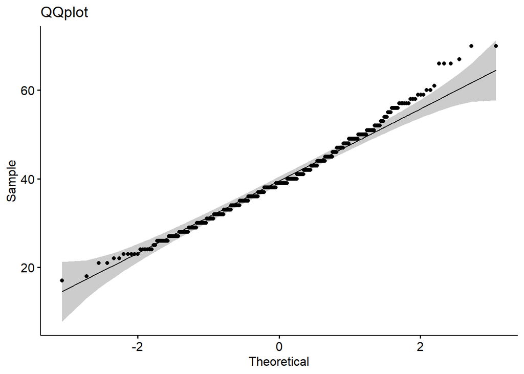

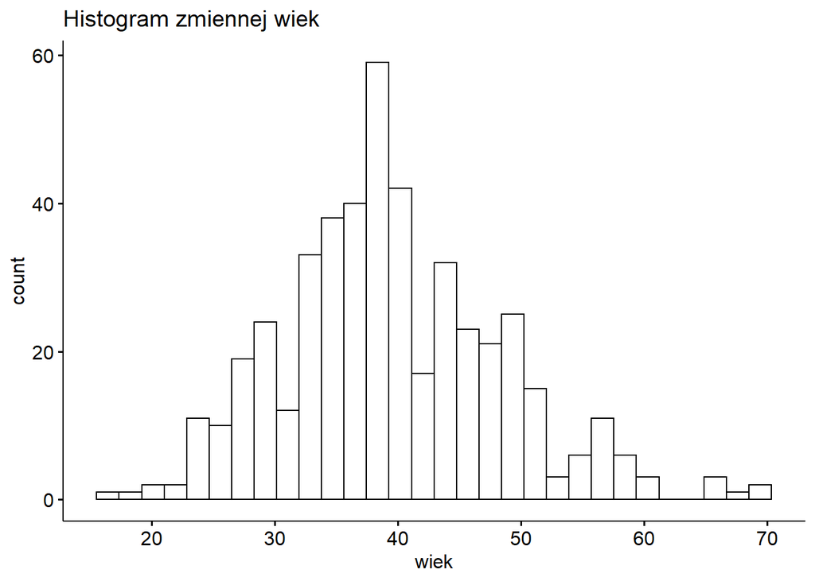

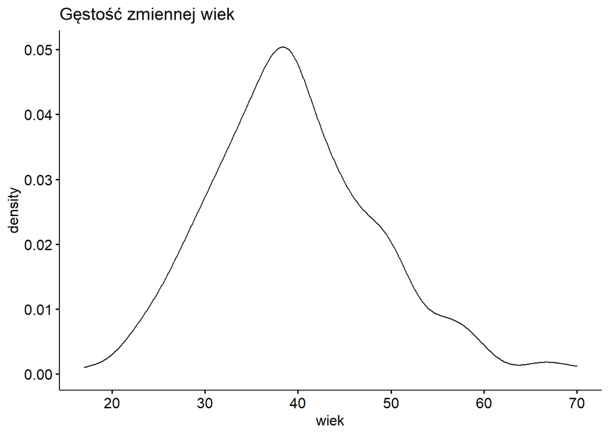

Ponieważ qqplot jest bliski wykresowi liniowemu, krzywa gęstości bliska rozkładowi normalnemu, stwierdzam, że to założenie jest uprawnione.

### Wyniki

Przedział ufności dla średniej: [ 38.42 , 40.57 ]

Przedział ufności dla odchylenia standardowego: [ 8.23 , 9.75 ]

## Kwantyle

Do obliczenia przedziałów ufności dla kwantyli użyję z metody zaimplementowanej w module R “jmuOutlier” powstałej na podstawie testu dwumianowego.

### Wyniki

Przedziały ufności dla następujących kwantyli:

$q_{0.25} = (32, 35)$  
$q_{0.5} = (38, 40)$  
$q_{0.75} = (43, 47)$

# Hipotezy na poziomie istotności 0.01

## Średnie wartości wagi pomiędzy osobami zamężnymi/żonatymi a pannami/kawalerami są równe

$H_0:$ Średnie wartości wagi pomiędzy osobami zamężnymi/żonatymi a pannami/kawalerami są równe

$H_1:$ Średnie wartości wagi pomiędzy osobami zamężnymi/żonatymi a pannami/kawalerami nie są równe

Korzystam z testu t-Studenta z założeniami:

- niezależność,
- normalność rozkładów,
- w przybliżeniu podobne wariancje między grupami.

Z analizy wykresów typu qqplot mogę stwierdzić, że rozkłady są bliskie normalnemu. Różnica wariancji jest o rząd niższa niż wariancje. Niezależność jest, ponieważ badam dwie niezależne grupy. Założenia wydają się być uprawnione.

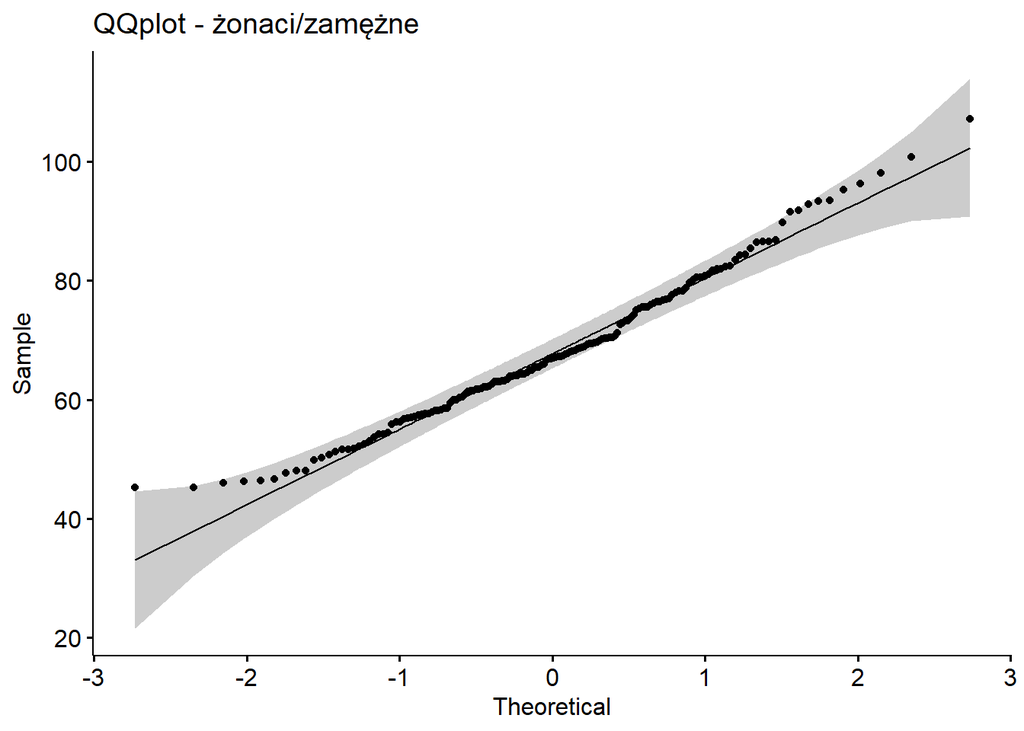

[figure not shown]

### Wyniki

P-wartość dla tego testu wynosi 0.9109, co oznacza, że na poziomie istotności 0.01 nie można odrzucić hipotezy $H_0$.

## Zmienna **liczba dzieci** i zmienna **wiek** są niezależne

$H_0:$ Liczba dzieci i wiek są niezależne  
$H_1:$ Liczba dzieci i wiek są zależne  
W celu zbadania niezależności skorzystamy z testu $\chi^2$ Pearsona.

Głównym założeniem testu $\chi^2$ Pearsona jest fakt, że zmienna (X,Y) jest zmienną skokową. Dla (liczba_dzieci, wiek) można się o tym przekonać patrząc na wykres:

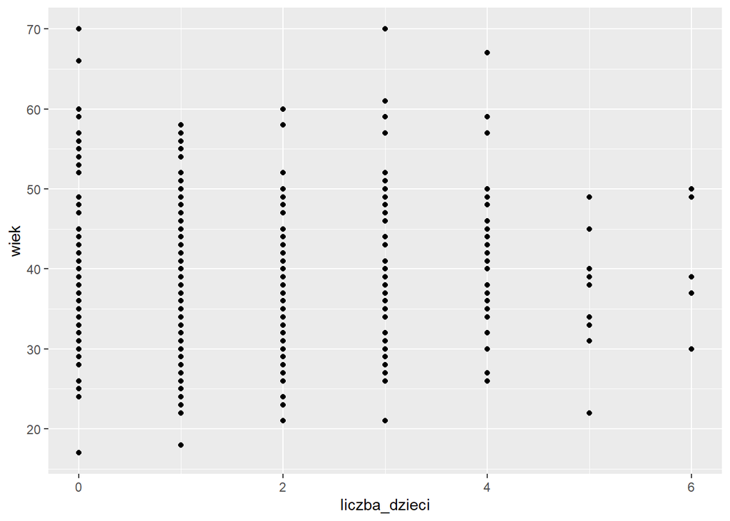

### Wyniki

P-wartość dla tego testu wynosi średnio około 0.2, co oznacza, że na poziomie istotności 0.01 nie można odrzucić hipotezy $H_0$.

## Zmienna **płeć** i zmienna **stan cywilny** są niezależne

$H_0:$ Płeć i stan cywilny są niezależne  
$H_1:$ Płeć i stan cywilny są zależne

W celu zbadania niezależności skorzystamy z testu $\chi^2$ Pearsona. Głównym założeniem testu $\chi^2$ Pearsona jest fakt, że zmienna (X,Y) jest zmienną skokową. Jest tak, bo obydwie zmienne są jakościowe.

### Wyniki

P-wartość dla tego testu średnio wynosi powyżej 0.01 (około 0.11), co oznacza, że na poziomie istotności 0.01 nie można odrzucić hipotezy $H_0$.

## Zmienna **wzrost** ma rozkład normalny z średnią 168 i odchyleniem standardowym 20

$H_0:$ Zmienna wzrost ma rozkład normalny z średnią 168 i odchyleniem standardowym 20  
$H_1:$ Zmienna wzrost nie ma rozkładu normalnego z średnią 168 i odchyleniem standardowym 20

Korzystam z testu Kołmogorowa-Smirnowa, test nie ma konkretnych założeń. Wykorzystuję test dla dwóch próbek i porównuje zmienną wzrost z losową próbką pobraną z $N(168,20)$.

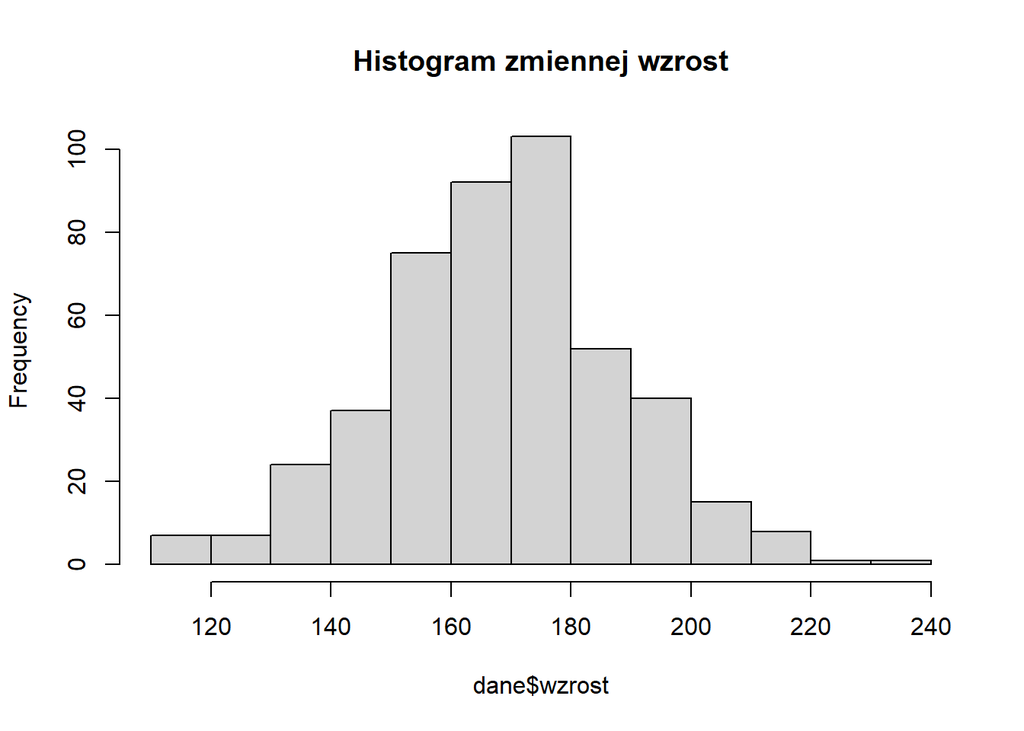

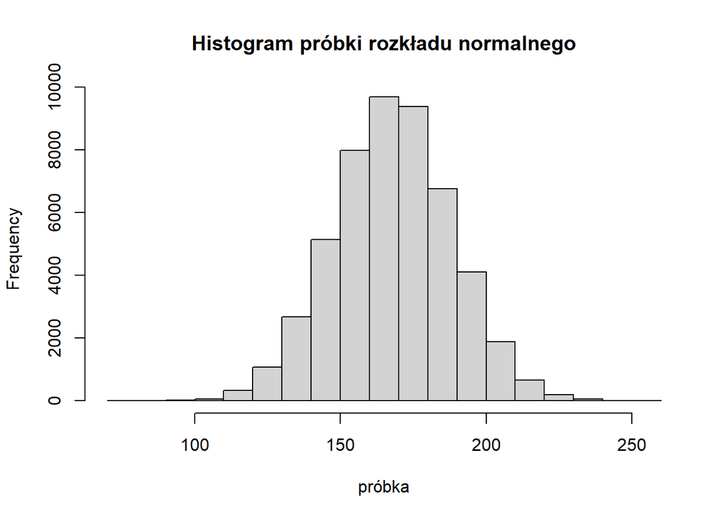

### Wyniki

P-wartość dla tego testu średnio wynosi powyżej 0.7, co oznacza, że na poziomie istotności 0.01 nie można odrzucić hipotezy $H_0$.

# Model regresji liniowej

Po przeanalizowaniu zależności zmiennej oszczędności od pozostałych zmiennych niezależnych, podjęłam decyzję, że nie będę modyfikować ich w celu poprawy modelu.

Dla modelu niewykluczającego żadnej zmiennej otrzymałam następujące wartości parametrów:  
$R^2 = 0.9673$  
$RSS = 102$  
$P-VAL < 2.2e-16$

Zmiennymi, których usunięcie nieznacznie poprawia podstawowy model, są zmienna stan_cywilny i plec. Jednak patrząc na poszczególne p-wartości, podjęłam decyzję, żeby wykluczyć zmienną plec, ponieważ dla niej p-wartość w modelu podstawowym była większa.

Ostatecznie parametry wybranego przeze mnie modelu wynoszą: $R^2 = 0.9674$  
$RSS = 101.9$  
$P-VAL < 2.2e-16$

Założenia modelu regresji liniowej:

1. Wartości zmiennych objaśniających są deterministyczne
2. Model jest postaci $Y = β_0 + β_1X_1 + . . . + β_pX_p + ε$
3. $ε$ wektor losowy niezależnych zmiennych losowych o identycznym rozkładzie
4. Błedy o średniej 0, homoskedastyczne i nieskorelowane.

## Analiza wykresów diagnostycznych

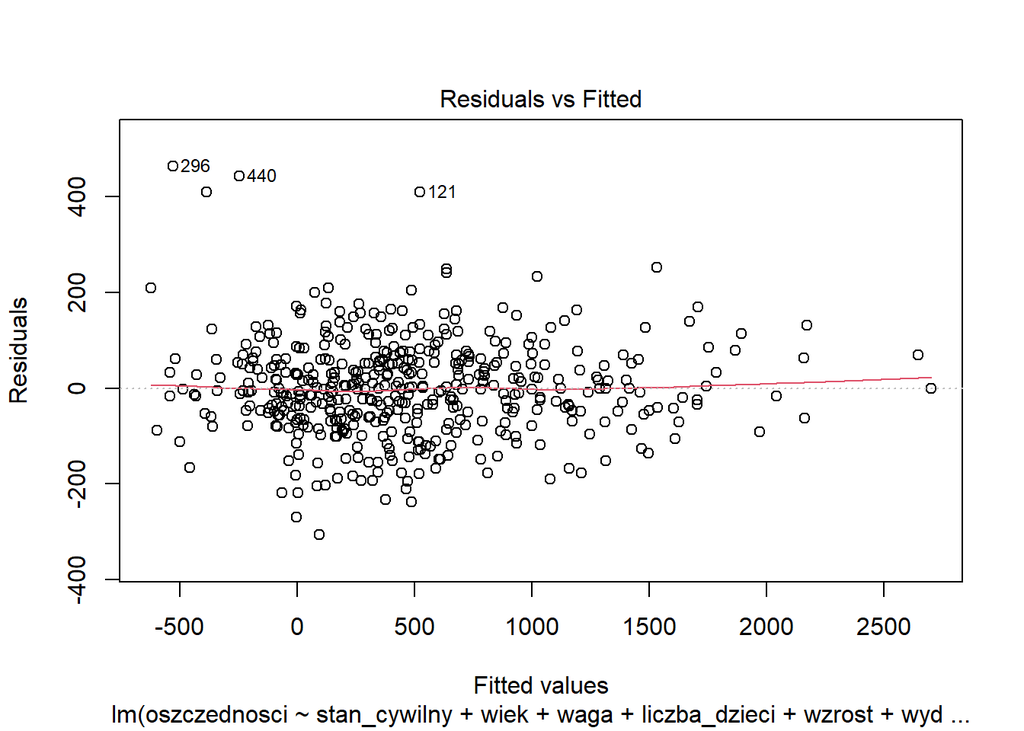

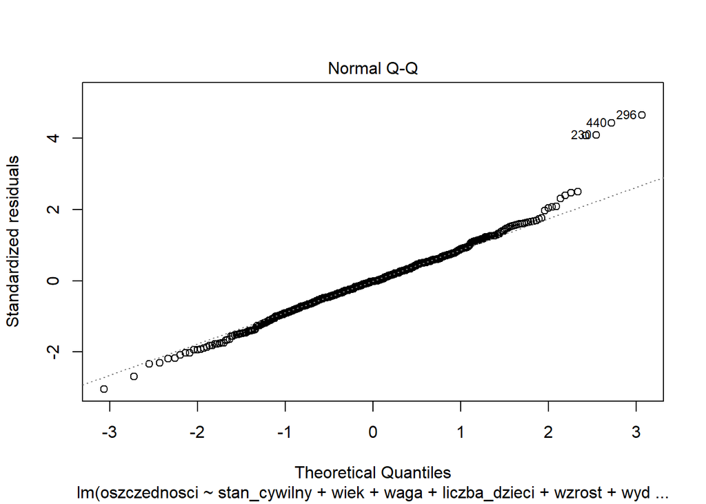

Rozkład residuów jest bardzo zbliżony do normalnego standardowego. Co pozwala sądzić, że mają średnią 0 i są homoskedastyczne.

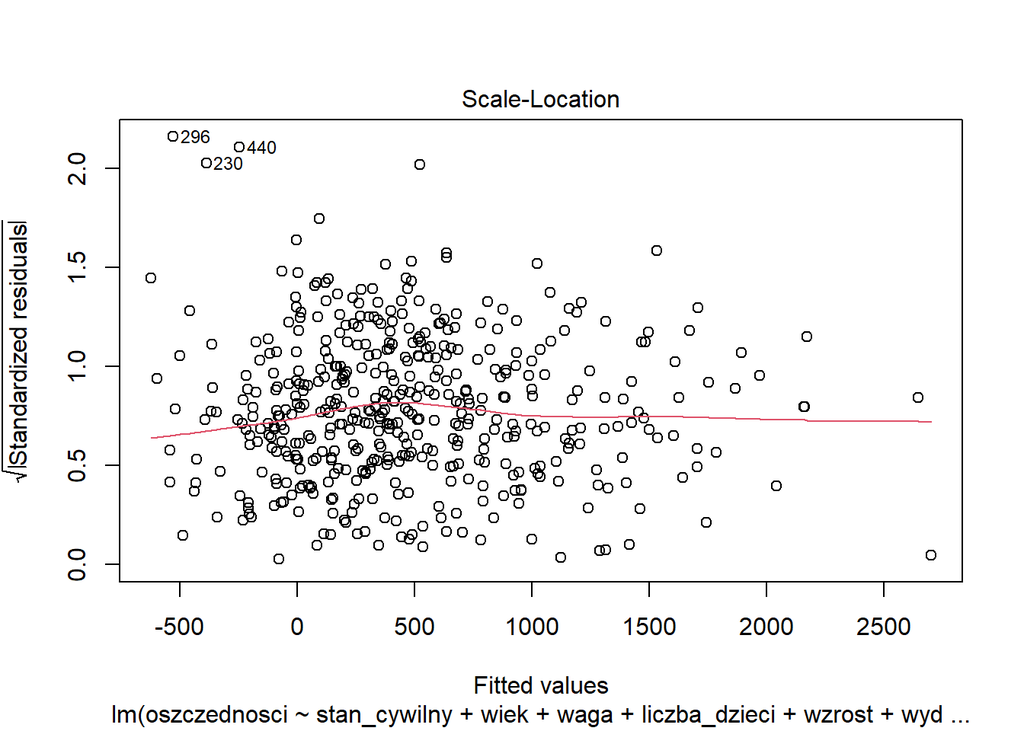

Ten wykres również pozwala się przekonać o homoskedastyczności błędów. Nie widać, żeby wariancja miała zależeć od wartości zmiennej objaśnianej.

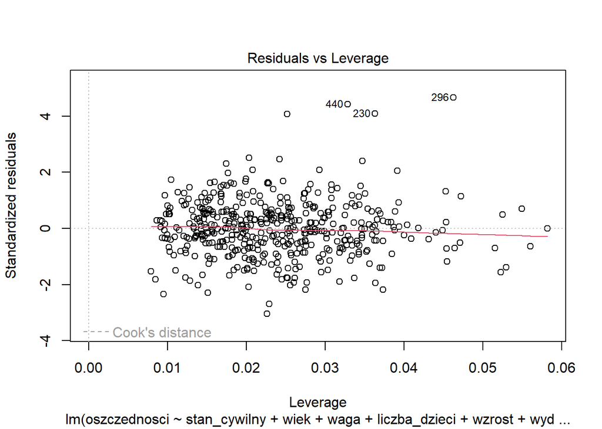

Z tego wykresu można odcztać obserwacje odstające, które zaburzają model. Za takie można uznać obserwacje o wysokiej dźwigni i nietypowych wartościach residuów.

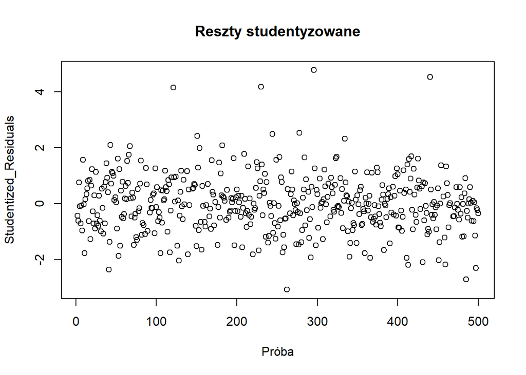

## Jak wyglądałby model po odrzuceniu obserwacji z resztami studentyzowanymi odchylonymi o więcej niż 3 od 0?

$R^2 = 0.9731$  
$RSS = 92.58$  
$P-VAL < 2.2e-16$

Szczególnie duża zmiana następuje dla $RSS$, natomiast $R^2$ również się poprawia.

### Wykresy diagnostyczne dla zmienionych danych

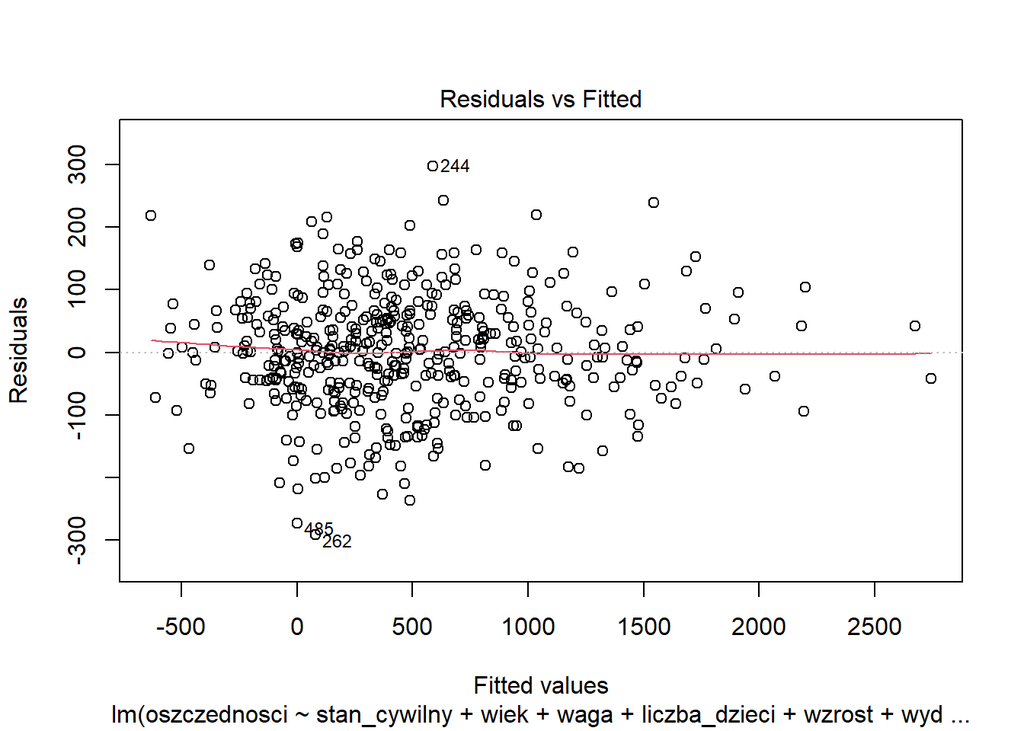

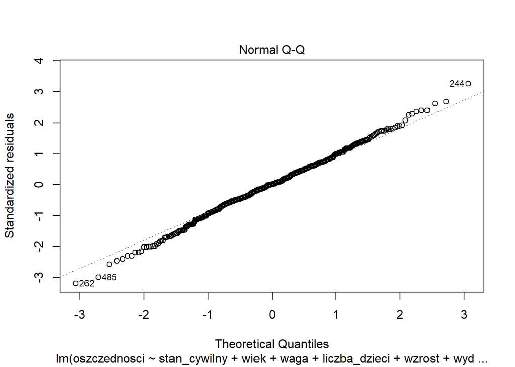

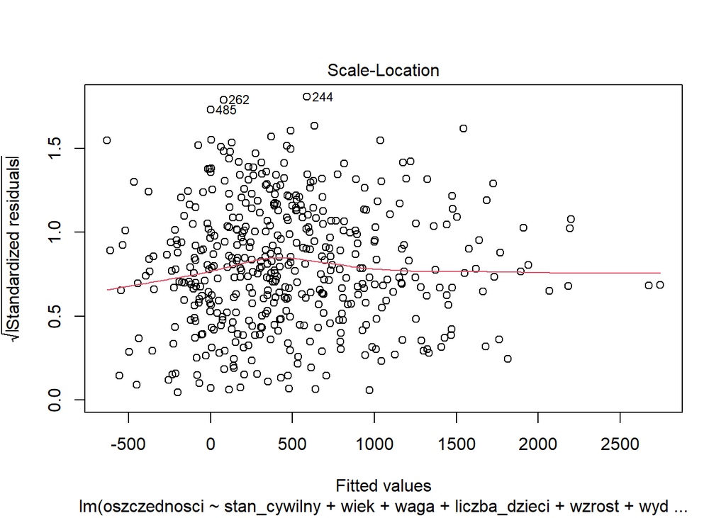

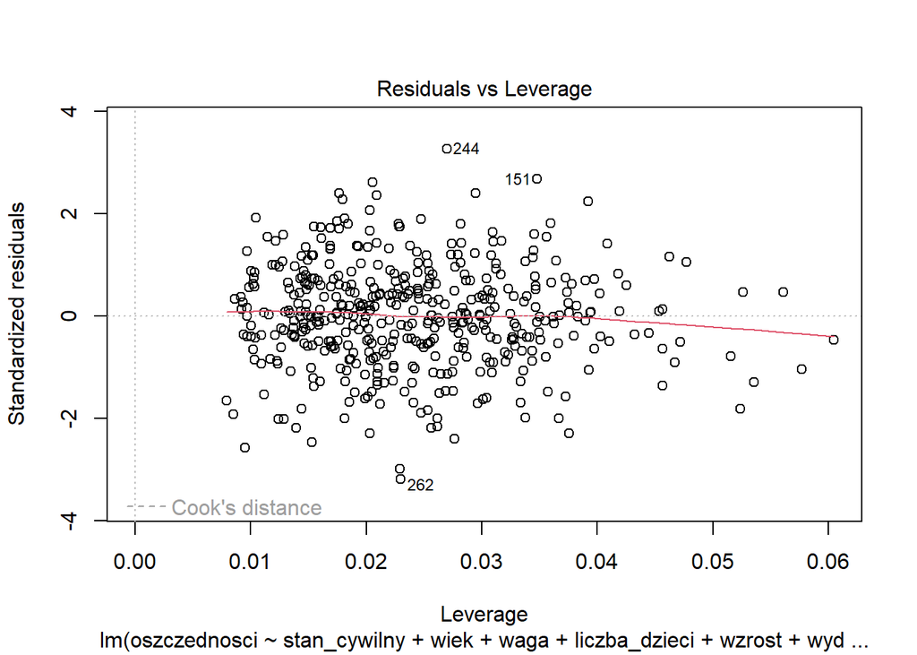

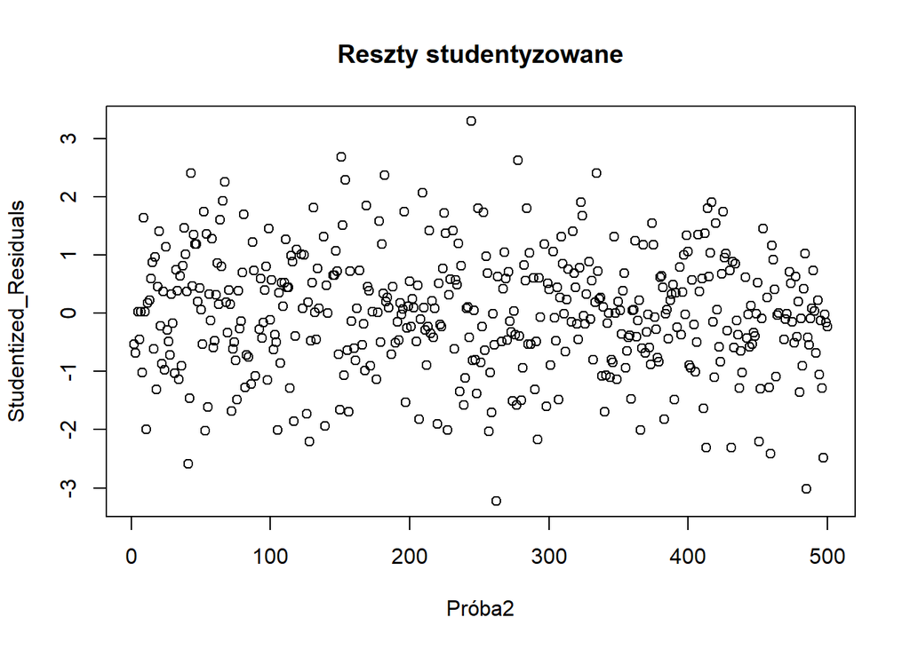